# Constrained analyses applied to an interaction network

Authors

Lisa Nicvert

Hervé Fritz

Stéphane Dray

```r
library(here)

library(ggplot2)
library(patchwork)
library(ggtext)

library(ade4)
library(adegraphics)

library(douconca)

library(effectsize)

library(metafor) # meta-analysis for Pearson coef

devtools::load_all()

theme_set(theme_linedraw() +
            theme(
      strip.background = element_rect(fill = "white", color = "black"),
      strip.text        = element_text(color = "black"),
      panel.background  = element_rect(fill = "white"),
      panel.grid = element_line(colour = "grey")
    )
)

# Paths
figures_folder <- here("figures")
out_folder <- here("outputs", "03_example_network", params$dataset)
input_folder <- here("outputs", "01_clean_data", params$dataset)

set.seed(42)
```

## Introduction

In this document, we analyze dataset Peru1 from ANDEAN frugivory dataset (Dehling et al. 2021) with correspondence analyses methods.

## Read data

First, read formatted data.

```r
interactions <- read.csv(file.path(input_folder, "interactions.csv"))
plant_traits <- read.csv(file.path(input_folder, "plant_traits.csv"))
bird_traits <- read.csv(file.path(input_folder, "bird_traits.csv"))
```

## Format data

We remove the species that have `NA` traits.

```r
bird_traits <- bird_traits |>
  tidyr::drop_na()

plant_traits <- plant_traits |>
  tidyr::drop_na()

# Keep the table with traits for export
bird_traits_codes <- bird_traits
plant_traits_codes <- plant_traits
```

We format the interaction matrix and filter out species that interact with $\leq$ 1 partners.

```r
# Convert data.frame to matrix
interactions <- df_to_matrix(interactions,
                             rows = "plant_species_code",
                             columns = "bird_species_code")

# Remove species that interact with few partners (if thr >= 2)
interactions <- filter_matrix(interactions, thr = params$thr)

# Format data
plant_traits <- plant_traits |>
  tibble::column_to_rownames("plant_species_code") |>
  dplyr::select(-plant_species)

bird_traits <- bird_traits |>
  tibble::column_to_rownames("bird_species_code") |>
  dplyr::select(-bird_species)
```

```r
# Filter
p <- intersect(rownames(interactions),
               rownames(plant_traits))
b <- intersect(colnames(interactions),
               rownames(bird_traits))

plant_traits <- plant_traits[p, ]
bird_traits <- bird_traits[b, ]
interactions <- interactions[p, b]
```

```r
if (params$transform_matrix == "log1p") {
  # Transform matrix counts using log(x + 1)
  interactions <- log(interactions + 1)
} else if (params$transform_matrix == "N2") {
  interactions <- douconca::ipf2N2(interactions)
}


if (params$log_transform_traits) {
  # Log-transform traits
  bird_traits <- bird_traits |>
    dplyr::mutate(across(c(KippsIndex, BillLength, BillWidth, Bodymass),
                         log))
  plant_traits <- plant_traits |>
    dplyr::mutate(across(c(meanL, meanD1, meanHeight, CropMass),
                         log))
}
```

```r
# Rename columns
plant_traits_labels <- c("fruit length", "fruit diameter", "plant height", "crop mass")
names(plant_traits_labels) <- colnames(plant_traits)

bird_traits_labels <- c("Kipp's index", "bill length", "bill width", "body mass")
names(bird_traits_labels) <- colnames(bird_traits)
```

```r
# Get data dimensions
r <- nrow(interactions)
c <- ncol(interactions)
l <- ncol(plant_traits)
k <- ncol(bird_traits)
```

```r
# Create viridis palette for rows
colrow <- viridisLite::viridis(nrow(interactions),
                               option = "G",
                               end = 0.9)
# Create viridis palette for columns
colco <- viridisLite::viridis(ncol(interactions),
                              option = "F",
                              end = 0.9)
```

## CA

First, perform simple correspondence analysis (CA): this will be useful for variance partitioning and for computing CCA and dc-CA with ade4.

```r
ca <- dudi.coa(interactions,
               scannf = FALSE,
               nf = min(c(r - 1, c - 1)))
```

## CCA with plant traits (Appendix S1 Section 3)

Then, perform constrained correspondence analysis (CCA) constrain with plant traits.

```r
cca_plants <- pcaiv(dudi = ca,
                    df = plant_traits,
                    scannf = FALSE,
                    nf = min(c(r - 1, c, l)))

(V <- cramers_v(interactions))
```

```
Cramer's V (adj.) |       95% CI
--------------------------------
0.31              | [0.29, 1.00]

- One-sided CIs: upper bound fixed at [1.00].
```

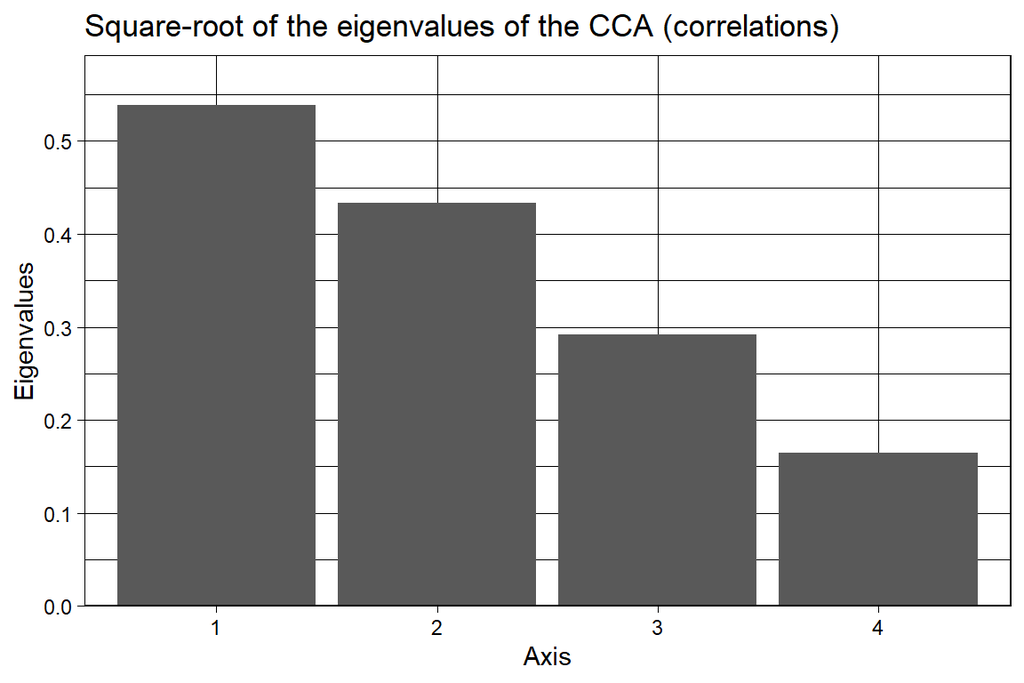

```r
plot_eig(sqrt(cca_plants$eig), showrank = TRUE) +
  ggtitle("Square-root of the eigenvalues of the CCA (correlations)")
```

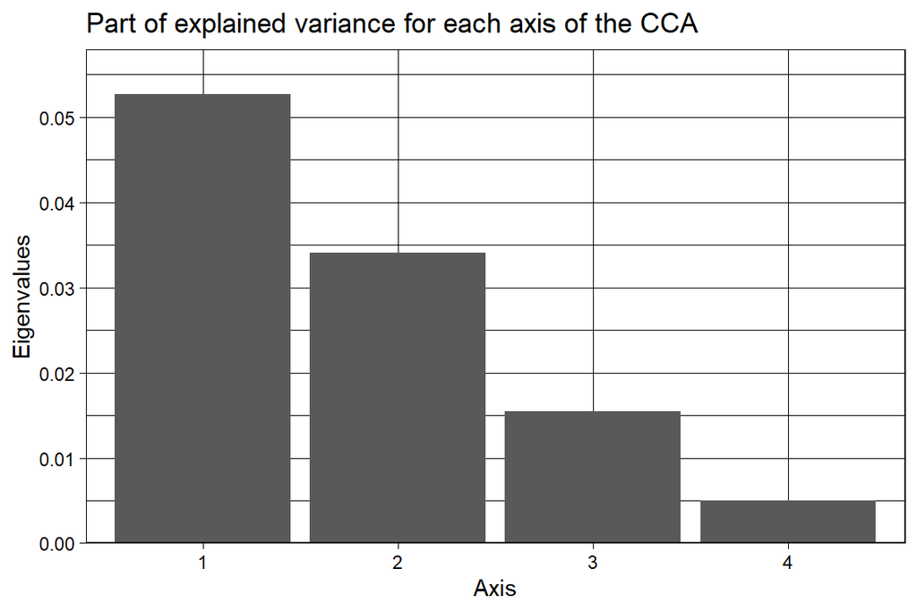

```r
plot_eig(cca_plants$eig/sum(ca$eig), showrank = TRUE) +
  ggtitle("Part of explained variance for each axis of the CCA")
```

```r
# Variation explained by first 2 axes
sum(cca_plants$eig[1:2])/sum(cca_plants$eig)
```

```
[1] 0.8095631
```

### Correlation circle

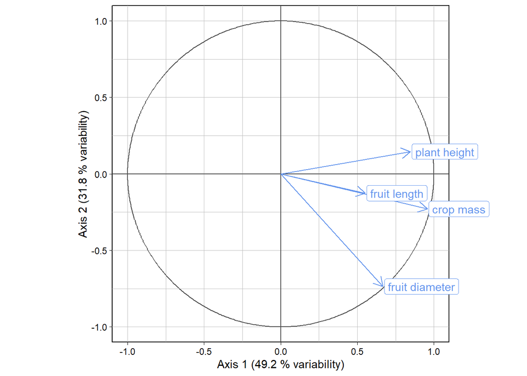

```r
plot_corcircle(cor = cca_plants$cor,
               col = params$colli,
               label = plant_traits_labels,
               eig = cca_plants$eig)
```

```r
if (!params$log_transform_traits & params$transform_matrix == "") {
  ggsave(file.path(figures_folder, "Fig_S1_S2a_cca_plants_corcircle.png"),
       width = 16, height = 13, units = "cm")
}
```

### Biplots

Let’s plot birds WA scores ($V^\star$) (`co`) at the mean of plants LC (linear combinations) scores $Z$ (`l1`) (bird niches).

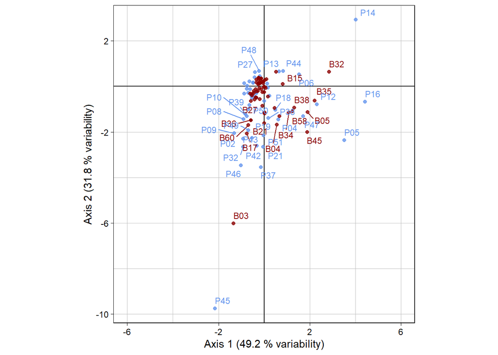

```r
# Plot bird niches
multiplot(indiv_row = cca_plants$l1,
          indiv_col = cca_plants$co,
          eig = cca_plants$eig,
          row_color = params$colli,
          col_color = params$colco,
          xlim = c(-6, 6),
          max.overlaps = 15,
          force = 3,
          force_pull = 0.1)
```

```r
if (!params$log_transform_traits & params$transform_matrix == "") {
  ggsave(file.path(figures_folder, "Fig_S1_S2b_cca_plants_bniches.png"),
       width = 13, height = 13, units = "cm")
}
```

We could also represent plants niches with plants WA (weighted averaging) scores $U^\star$ (`ls`) at the mean of birds scores $V$ (`c1`).

## CCA with bird traits (Appendix S1 Section 4)

Then, we constrain axes with bird traits.

```r
ca_t <- dudi.coa(t(interactions),
                 scannf = FALSE,
                 nf = min(c(r - 1, c - 1)))

cca_birds <- pcaiv(dudi = ca_t,
                   df = bird_traits,
                   scannf = FALSE,
                   nf = min(c(c - 1, r, k)))
```

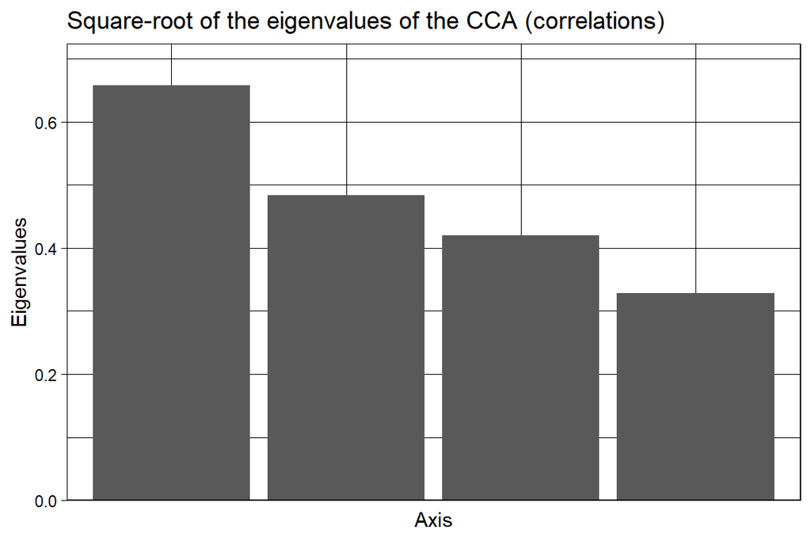

```r
plot_eig(sqrt(cca_birds$eig)) + ggtitle("Square-root of the eigenvalues of the CCA (correlations)")
```

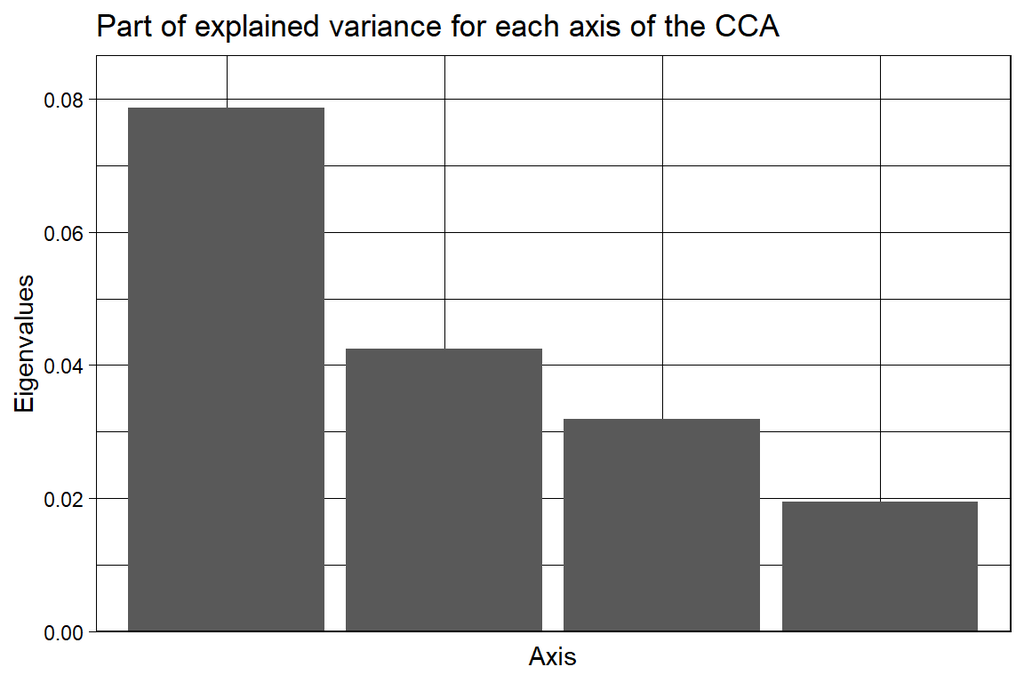

```r
plot_eig(cca_birds$eig/sum(ca$eig)) +
  ggtitle("Part of explained variance for each axis of the CCA")
```

```r
# Variation explained by first 2 axes
sum(cca_birds$eig[1:2])/sum(cca_birds$eig)
```

```
[1] 0.7016265
```

### Correlation circle

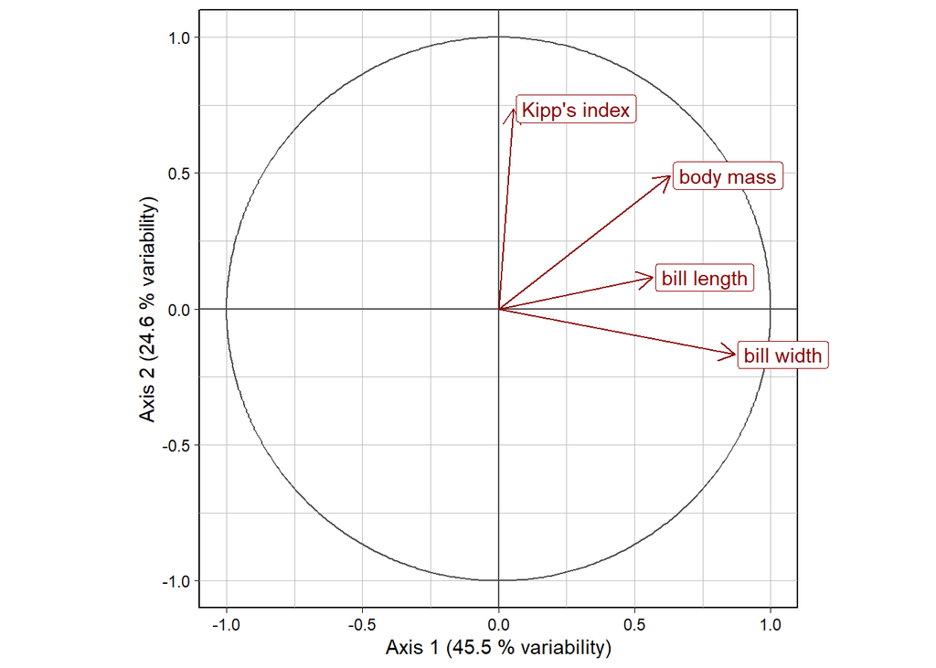

```r
# Invert first axis (easier comparison with dc-CA)
cor <- cca_birds$cor
cor[, 1] <- -cor[, 1]
plot_corcircle(cor = cor,
               col = params$colco,
               label = bird_traits_labels,
               eig = cca_birds$eig)
```

```r
if (!params$log_transform_traits & params$transform_matrix == "") {
  ggsave(file.path(figures_folder, "Fig_S1_S3a_cca_birds_corcircle.png"),
       width = 14, height = 11, units = "cm")
}
```

### Biplots

We plot plants WA scores ($V^\star$) (`co`) at the mean of birds LC scores $Z$ (`l1`) (plants niches).

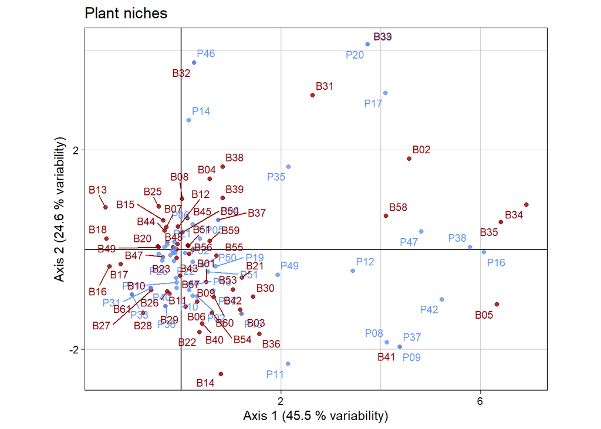

```r
# Invert first axis
l1 <- cca_birds$l1
l1[, 1] <- - l1[, 1]

co <- cca_birds$co
co[, 1] <- - co[, 1]

# Plants niches
multiplot(indiv_row = l1,
          indiv_col = co,
          eig = cca_birds$eig,
          row_color = params$colco,
          col_color = params$colli,
          # xlim = c(-2, 7),
          # ylim = c(-6, 5),
          max.overlaps = 15,
          force = 3,
          force_pull = 0.1) +
  ggtitle("Plant niches")
```

```r
if (!params$log_transform_traits & params$transform_matrix == "") {
  ggsave(file.path(figures_folder, "Fig_S1_S3b_cca_birds_pniches.png"),
       width = 13, height = 11, units = "cm")
}
```

## dc-CA

Now we perform a dc-CA, constrained by plant and bird species traits.

```r
dcca <- dpcaiv(dudi = ca,
               dfR = plant_traits,
               dfQ = bird_traits,
               scannf = FALSE,
               nf = min(k, l))
```

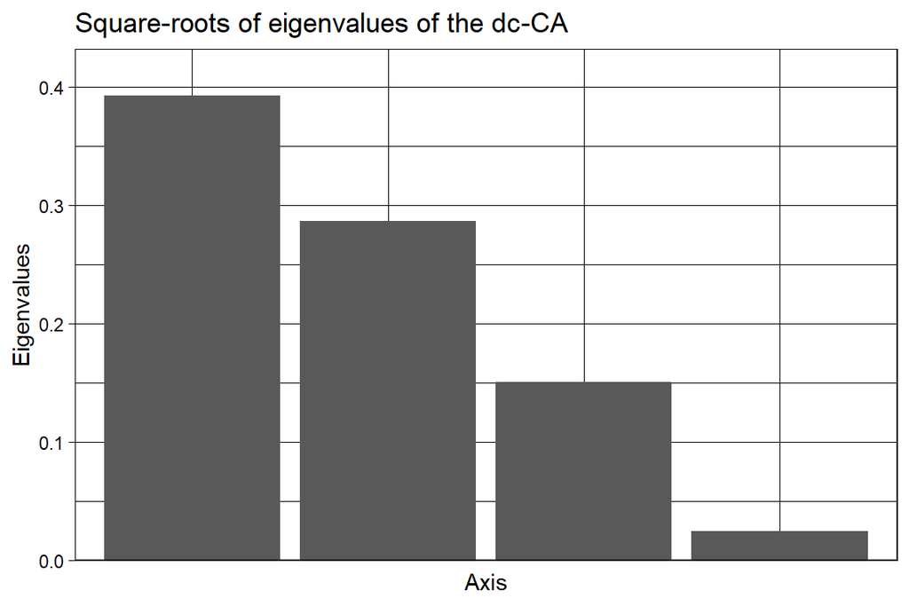

```r
plot_eig(sqrt(dcca$eig)) + ggtitle("Square-roots of eigenvalues of the dc-CA")
```

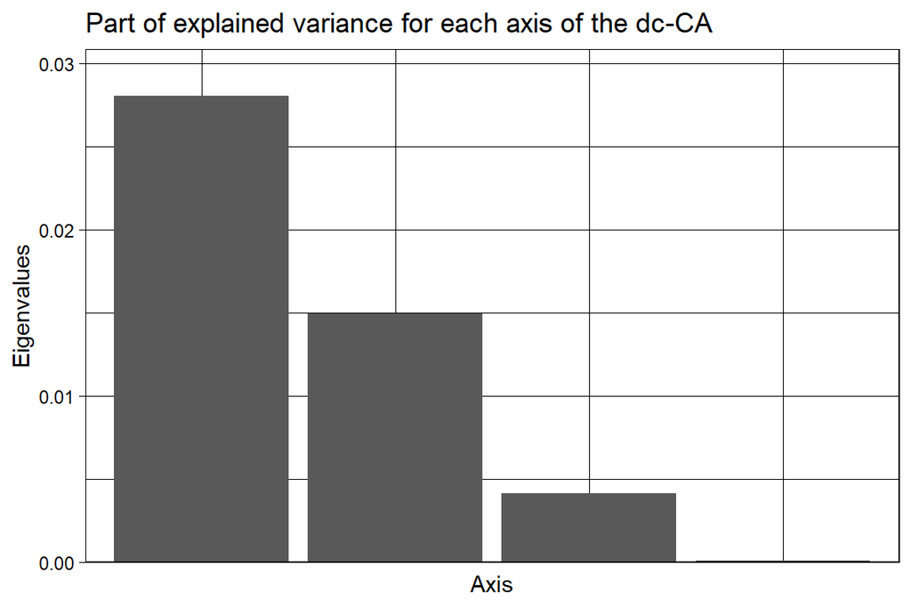

```r
plot_eig(dcca$eig/sum(ca$eig)) +
  ggtitle("Part of explained variance for each axis of the dc-CA")
```

```r
# Correlation between traits
sqrt(dcca$eig[1:2])
```

```
[1] 0.3930677 0.2870242
```

```r
# Variation explained by first 2 axes
sum(dcca$eig[1:2])/sum(dcca$eig)
```

```
[1] 0.9098901
```

### Correlation circle

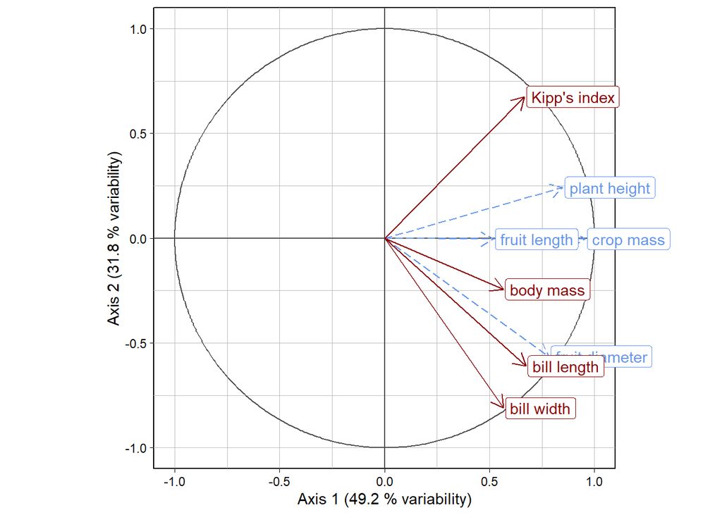

```r
# Invert axes to plot for transformed matrix
if (params$transform_matrix == "log1p") {
  corR_plot <- -dcca$corR
  corQ_plot <- -dcca$corQ
} else if (params$transform_matrix == "N2") {
  corR_plot <- dcca$corR
  corQ_plot <- dcca$corQ
  corR_plot[, 2] <- -corR_plot[, 2]
  corQ_plot[, 2] <- -corQ_plot[, 2]
} else {
  corR_plot <- dcca$corR
  corQ_plot <- dcca$corQ
}

plot_corcircle(cor = corR_plot,
               col = params$colli,
               label = plant_traits_labels,
               cor2 = corQ_plot,
               col2 = params$colco,
               lty = "longdash",
               lty2 = "solid",
               label2 = bird_traits_labels,
               eig = cca_plants$eig)
```

```r
if (!params$log_transform_traits & params$transform_matrix == "") {
  ggsave(file.path(figures_folder, "Fig_3a_dcca_corcircle_orig.svg"),
       width = 15, height = 11, units = "cm")
} else if (params$log_transform_traits){
  ggsave(file.path(figures_folder, "Fig_S1_S6a_dcca_corcircle_log.png"),
       width = 15, height = 11, units = "cm")
} else if (params$transform_matrix == "N2"){
  ggsave(file.path(figures_folder, "Fig_S1_S8a_dcca_corcircle_N2.png"),
       width = 15, height = 11, units = "cm")
}
```

### Biplots

We plot the biplots with a scaling appropriate to represent species niches:

- to represent plants niches: plants WA scores $U^\star$ (`lsR`) at the mean of birds LC scores $V$ (`c1`).
- to represent bird niches: birds WA scores ($V^\star$) (`lsQ`) at the mean of plants LC scores $U$ (`l1`).

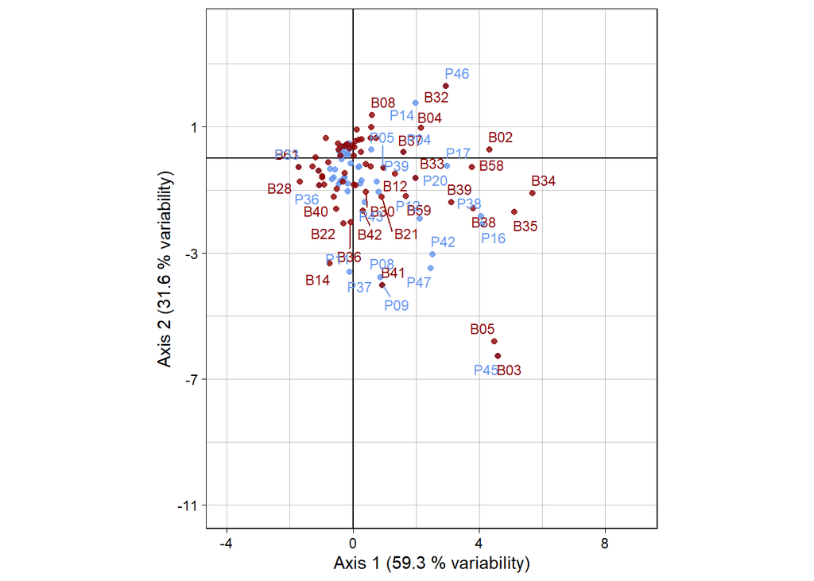

```r
if (!params$log_transform_traits & params$transform_matrix == "") {
  # Only use custom limits for main text analysis
  xlim <- c(-4, 9)
  ylim <- c(-11, 4)
} else {
  # For suppmat analyses, keep default
  xlim <- NULL
  ylim <- NULL
}

grad <- 4

# Invert axes to plot for transformed matrix
if (params$transform_matrix == "log1p") {
  lsR_plot <- -dcca$lsR
  c1_plot <- -dcca$c1

  l1_plot <- -dcca$l1
  lsQ_plot <- -dcca$lsQ
} else if (params$transform_matrix == "N2") {
  lsR_plot <- dcca$lsR
  lsR_plot[, 2] <- -lsR_plot[, 2]

  c1_plot <- dcca$c1
  c1_plot[, 2] <- -c1_plot[, 2]

  l1_plot <- dcca$l1
  l1_plot[, 2] <- -l1_plot[, 2]

  lsQ_plot <- dcca$lsQ
  lsQ_plot[, 2] <- -lsQ_plot[, 2]
} else {
  lsR_plot <- dcca$lsR
  c1_plot <- dcca$c1

  l1_plot <- dcca$l1
  lsQ_plot <- dcca$lsQ
}

# Plant niches
multiplot(indiv_row = lsR_plot,
          indiv_col = c1_plot,
          eig = dcca$eig,
          row_color = params$colli,
          col_color = params$colco,
          xlim = xlim,
          ylim = ylim,
          grad = grad,
          max.overlaps = 15,
          force = 3,
          force_pull = 0.1)
```

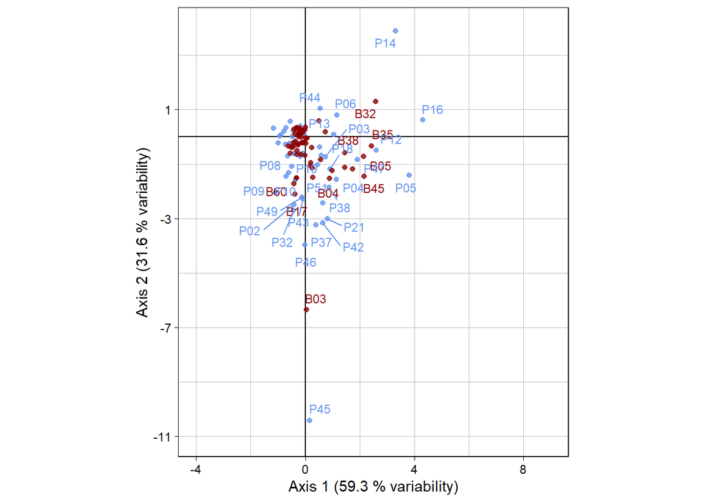

```r
if (!params$log_transform_traits & params$transform_matrix == "") {
  ggsave(file.path(figures_folder, "Fig_3b_dcca_pniches.png"),
         width = 11, height = 11, units = "cm")
} else if (params$log_transform_traits) {
  ggsave(file.path(figures_folder, "Fig_S1_S6b_dcca_pniches_log.png"),
         width = 11, height = 11, units = "cm")
} else if (params$transform_matrix == "N2") {
  ggsave(file.path(figures_folder, "Fig_S1_S8b_dcca_pniches_N2.png"),
         width = 11, height = 11, units = "cm")
}

# Bird niches
multiplot(indiv_row = l1_plot,
          indiv_col = lsQ_plot,
          eig = dcca$eig,
          row_color = params$colli,
          col_color = params$colco,
          xlim = xlim,
          ylim = ylim,
          grad = grad,
          max.overlaps = 15,
          force = 3,
          force_pull = 0.1)
```

```r
if (!params$log_transform_traits & params$transform_matrix == "") {
  ggsave(file.path(figures_folder, "Fig_3c_dcca_bniches.png"),
       width = 11, height = 11, units = "cm")
} else if (params$log_transform_traits){
  ggsave(file.path(figures_folder, "Fig_S1_S6c_dcca_bniches_log.png"),
       width = 11, height = 11, units = "cm")
} else if (params$transform_matrix == "N2") {
  ggsave(file.path(figures_folder, "Fig_S1_S8c_dcca_bniches_N2.png"),
       width = 11, height = 11, units = "cm")
}
```

## Variance decomposition

The analyses above are linked through the following variance decomposition:

$$\underbrace{I(\text{total})}_{[t]} = \underbrace{I(\text{birds traits})}_{[c]} + \underbrace{I(\text{plants traits})}_{[a]} + \underbrace{I(\text{matching})}_{[b]} + \underbrace{I(\text{residual})}_{[d]}$$
where $I(x)$ denotes the inertia of $x$ (also denoted by letters between brackets).

### Figure

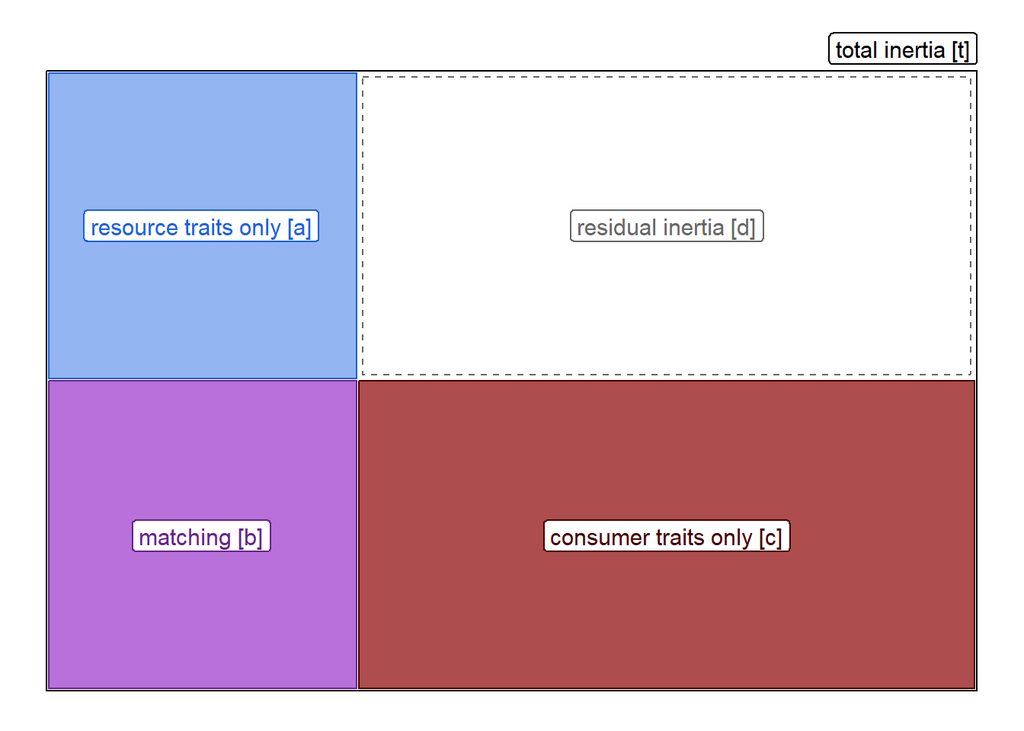

```r
# Graph parameters
xmax <- 15
ymax <- 10
width <- 5 # width of resource/consumer inertia
rpad <- 0.1 # padding for outline of the residual inertia
mar <- 0.1
inline <- 0.04

# The rectangles
df_rect <- data.frame(xmin = c(0, width+inline, 0+inline, 0+inline, width+rpad),
                      xmax = c(xmax, xmax-inline, width, width, xmax-rpad),
                      ymin = c(0, 0+inline, width+inline, 0+inline, width+rpad),
                      ymax = c(ymax, width, ymax-inline, width, ymax-rpad),
                      group = c("tot",
                                "consumer_traits", "resource_traits",
                                "matching", "res"))

# Text annotations
annotate <- data.frame(x = c(xmax,
                             width+(xmax-width)/2, width/2,
                             width/2, width+(xmax-width)/2),
                       y = c(ymax+mar,
                             width/2, width+(ymax-width)/2,
                             width/2, width+(ymax-width)/2),
                       label = c("total inertia [t]",
                                 "consumer traits only [c]", "resource traits only [a]",
                                 "matching [b]", "residual inertia [d]"),
                       group = df_rect$group)

palette_fill <- c("white", "darkred", "cornflowerblue", "darkorchid", "transparent")
names(palette_fill) <- df_rect$group

palette_col <- c("black", "#470000", "#1B61E4", "darkorchid4", "grey40")
names(palette_col) <- annotate$group

ggplot(df_rect, aes(col = group)) +
  geom_rect(aes(xmin = xmin, xmax = xmax,
                ymin = ymin, ymax = ymax,
                group = group, fill = group),
            alpha = c(1, rep(0.7, 3), 0),
            linetype = c(rep("solid", 4), "dashed"),
            show.legend = FALSE) +
  geom_label(data = annotate,
            aes(x = x, y = y, label = label),
            label.size = 0.5,
            vjust = c(0, 0.5, 0.5, 0.5, 0.5),
            hjust = c(1, 0.5, 0.5, 0.5, 0.5),
            size = 4,
            show.legend = FALSE) +
  coord_fixed() +
  ylim(0, ymax + 0.5) +
  scale_fill_manual(values = palette_fill) +
  scale_color_manual(values = palette_col) +
  ggplot2::theme_void()
```

```r
ggsave(file.path(figures_folder,
                 "Fig_2_variance_partitioning.png"),
       width = 15, height = 10.5, units = "cm")
```

### Values

Here, we correct the variance decomposition using the permutational form of adjustment from Peres-Neto et al. (2006) using the `ade4::dvaripart` function.

```r
vp <- dvaripart(Y = ca,
                dfR = plant_traits,
                dfQ = bird_traits,
                nrepet = 999)

vp
```

```
Variation Partitioning
class: dvaripart list

Test of fractions:
class: krandtest lightkrandtest
Monte-Carlo tests
Call: dvaripart(Y = ca, dfR = plant_traits, dfQ = bird_traits, nrepet = 999)

Number of tests:   4

Adjustment method for multiple comparisons:   none
Permutation number:   999
         Test        Obs   Std.Obs   Alter Pvalue
1       ab(R) 0.10718683 0.9230509 greater  0.165
2       bc(Q) 0.17272374 6.2001406 greater  0.001
3 b(RQ)_Rperm 0.04732532 3.1722240 greater  0.004
4 b(RQ)_Qperm 0.04732532 4.7998937 greater  0.001


Individual fractions:
         a          b          c          d
0.05986151 0.04732532 0.12539842 0.76741475

Adjusted fractions:
           a            b            c            d
-0.004257121  0.026978913  0.101694267  0.875583942
```

Get the correlation between axes of dc-CA:

```r
# Correlation between axes
dcca$eig
```

```
[1] 0.1545022493 0.0823828868 0.0228300265 0.0006296275
```

```r
# Part of trait matching explained
dcca$eig/sum(dcca$eig)
```

```
[1] 0.593452434 0.316437624 0.087691505 0.002418437
```

```r
sum(dcca$eig[1:2])/sum(dcca$eig)
```

```
[1] 0.9098901
```

Get the uncorrected inertia:

```r
# Plant traits [a]
sum(cca_plants$eig) - sum(dcca$eig)
```

```
[1] 0.3293085
```

```r
# Bird traits [c]
sum(cca_birds$eig) - sum(dcca$eig)
```

```
[1] 0.6898384
```

```r
# Trait matching [b]
sum(dcca$eig)
```

```
[1] 0.2603448
```

```r
# Residual [d]
sum(ca$eig) - (sum(cca_plants$eig) + sum(cca_birds$eig) - sum(dcca$eig))
```

```
[1] 4.221681
```

```r
# Total [t]
sum(ca$eig)
```

```
[1] 5.501173
```

## Species details tables (Appendix S1 Section 1)

The code below exports trait tables with species names and codes.

```r
# Birds
bird_traits_codes$bird_species_name <- gsub("_", " ",
                                            bird_traits_codes$bird_species)
bird_traits_codes$bird_species <- paste0("\\textit{",
                                         bird_traits_codes$bird_species_name,"}")

if (!dir.exists(out_folder)) {
  dir.create(out_folder, recursive = TRUE, showWarnings = FALSE)
}

# Remove last column without textit
bird_traits_codes_write <- bird_traits_codes[, c("bird_species_code", "bird_species",
                                                 "KippsIndex", "BillLength", "BillWidth", "Bodymass")]
write.table(bird_traits_codes_write, sep = " & ",
            eol = " \\\\\n",
            quote = FALSE,
            col.names = FALSE, row.names = FALSE,
            file = file.path(out_folder, "birds_latex.txt"))

# Plants
plant_traits_codes$plant_species_name <- gsub("_", " ",
                                              plant_traits_codes$plant_species)
plant_traits_codes$plant_species <- paste0("\\textit{",
                                             plant_traits_codes$plant_species_name,"}")

# Remove last column without textit
plant_traits_codes_write <- plant_traits_codes[, c("plant_species_code", "plant_species",
                                                   "meanL", "meanD1", "meanHeight", "CropMass")]
write.table(plant_traits_codes_write, sep = " & ",
            eol = " \\\\\n",
            quote = FALSE,
            col.names = FALSE, row.names = FALSE,
            file = file.path(out_folder, "plants_latex.txt"))
```

## Traits distribution (Appendix S1 Section 2)

Plot histograms of trait values.

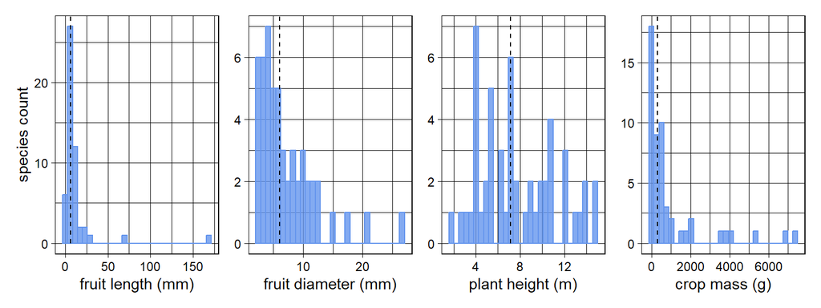

```r
plant_traits_labels_units <- paste(plant_traits_labels,
                                   c("(mm)", "(mm)", "(m)", "(g)"))
names(plant_traits_labels_units) <- names(plant_traits)

glist <- list()
for (colname in colnames(plant_traits)) {
  gr <- ggplot(plant_traits) +
    geom_histogram(aes(x = .data[[colname]]),
                 fill = params$colli,
                 col =  params$colli,
                 alpha = 0.8) +
    annotate("segment",
             x = median(plant_traits[[colname]]),
             xend = median(plant_traits[[colname]]),
             y = 0, yend = Inf,
             linetype = "dashed") +
    xlab(plant_traits_labels_units[colname]) +
    ylab("species count") +
    theme_linedraw()

  glist <- c(glist, list(gr))
}

wrap_plots(glist) +
  plot_layout(axis_titles = "collect_y", nrow = 1)
```

```r
if (!params$log_transform_traits & params$transform_matrix == "") {
  ggsave(file.path(figures_folder, "Fig_S1_S1a_plant_traits.png"),
       width = 26, height = 7, units = "cm")
}
```

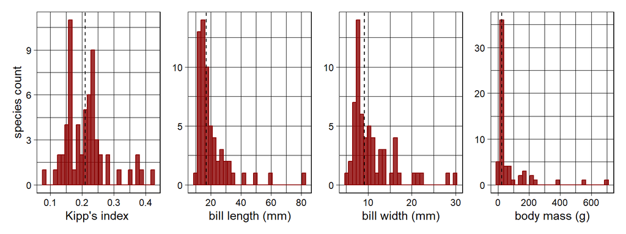

```r
bird_traits_labels_units <- paste(bird_traits_labels,
                                   c("", "(mm)", "(mm)", "(g)"))
names(bird_traits_labels_units) <- names(bird_traits_labels)

glist <- list()

for (colname in colnames(bird_traits)) {
  g <- ggplot(bird_traits) +
    geom_histogram(aes(x = .data[[colname]]),
                   fill = params$colco,
                   col =  params$colco,
                   alpha = 0.8) +
    annotate("segment",
             x = median(bird_traits[[colname]]),
             xend = median(bird_traits[[colname]]),
             y = 0, yend = Inf,
             linetype = "dashed") +
    xlab(bird_traits_labels_units[colname]) +
    ylab("species count") +
    theme_linedraw()

  glist <- c(glist, list(g))
}

wrap_plots(glist) +
  plot_layout(axis_titles = "collect_y", nrow = 1)
```

```r
if (!params$log_transform_traits & params$transform_matrix == "") {
  ggsave(file.path(figures_folder, "Fig_S1_S1b_bird_traits.png"),
       width = 26, height = 7, units = "cm")
}
```

## Residuals of trait-based interaction niches (Appendix S1 Section 5)

For constrained analyses, we have two sets of scores for constrained species: comparing them is a way to measure the model fit.

### dc-CA

We plot bird and plants coordinates:

- from their traits: the LC scores $U$ and $V$ (non-normalized) (respectively `li` and `co`)
- from their “latent traits: the WA scores $U^\star$ and $V^\star$ (respectively `lsR` and `lsQ`)

The figure below corresponds to Figure 1 from Appendix S1 Section S5.

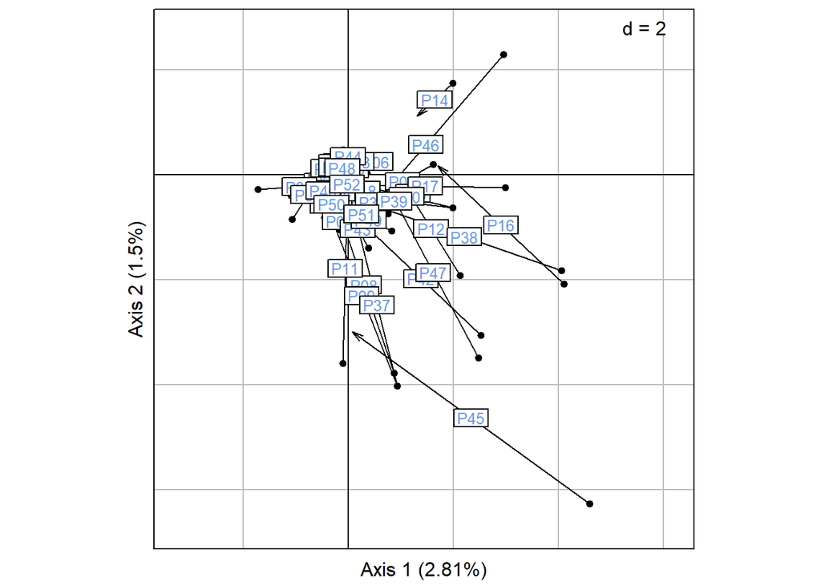

```r
percent <- (dcca$eig/sum(ca$eig))*100
xlab <- paste0("Axis 1 (", round(percent[1], 2), "%)")
ylab <- paste0("Axis 2 (", round(percent[2], 2), "%)")

axis_title_padding <- 1.3
padding <- 1

# Difference between niche and traits for plants
# lsR -> li

# if (!params$log_transform_traits & params$transform_matrix == "") {
#   png(file.path(figures_folder, "Fig_S1_S4b_diff_plants.png"),
#       width = 15, height = 15, units = "cm", res = 300)
# }
s.match(dcca$lsR, dcca$li, xax = 1, yax = 2,
        plabels.col = params$colli,
        plabels.cex = 0.8,
        xlab = xlab, ylab = ylab,
        layout.heights = list(axis.xlab.padding = axis_title_padding,
                              bottom.padding = padding,
                              top.padding = padding),
        layout.widths = list(ylab.axis.padding = axis_title_padding,
                             left.padding = padding,
                             right.padding = padding))
```

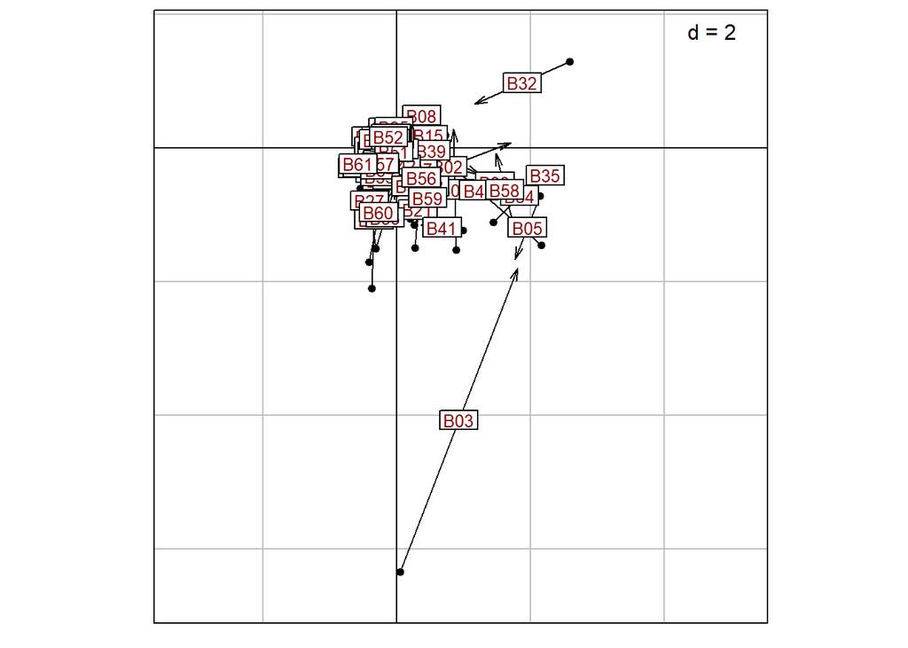

```r
# if (!params$log_transform_traits & params$transform_matrix == "") {
#   dev.off()
# }

# Difference between niche and traits for birds
# lsQ -> li
# if (!params$log_transform_traits & params$transform_matrix == "") {
#   png(file.path(figures_folder, "Fig_S1_S4a_diff_birds.png"),
#       width = 15, height = 15, units = "cm", res = 300)
# }
s.match(dcca$lsQ, dcca$co, xax = 1, yax = 2,
        plabels.col = params$colco,
        plabels.cex = 0.8,
        layout.heights = list(axis.xlab.padding = axis_title_padding,
                              bottom.padding = padding,
                              top.padding = padding),
        layout.widths = list(ylab.axis.padding = axis_title_padding,
                             left.padding = padding,
                             right.padding = padding))
```

```r
# if (!params$log_transform_traits & params$transform_matrix == "") {
#   dev.off()
# }
```

### CCA with plant traits

We plot plant coordinates:

- from their traits: the LC scores $Z_0$ (non-normalized) (`li`)
- from birds’ scores (“latent traits”): the WA scores $U^\star$ (`ls`)

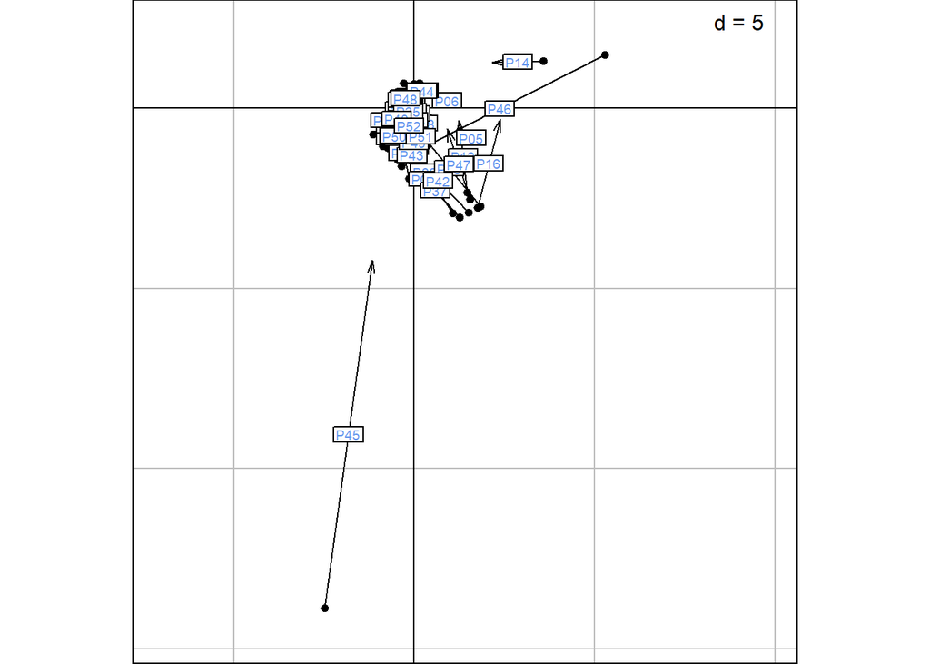

```r
# ls -> li
s.match(cca_plants$ls, cca_plants$li,
        xax = 1, yax = 2,
        plabels.col = params$colli,
        plabels.cex = 0.6)
```

### CCA with bird traits

We plot bird coordinates:

- from their traits: the LC scores $Z_0$ (non-normalized) (`li`)
- from plants’ scores (“latent traits”): the WA scores $U^\star$ (`ls`)

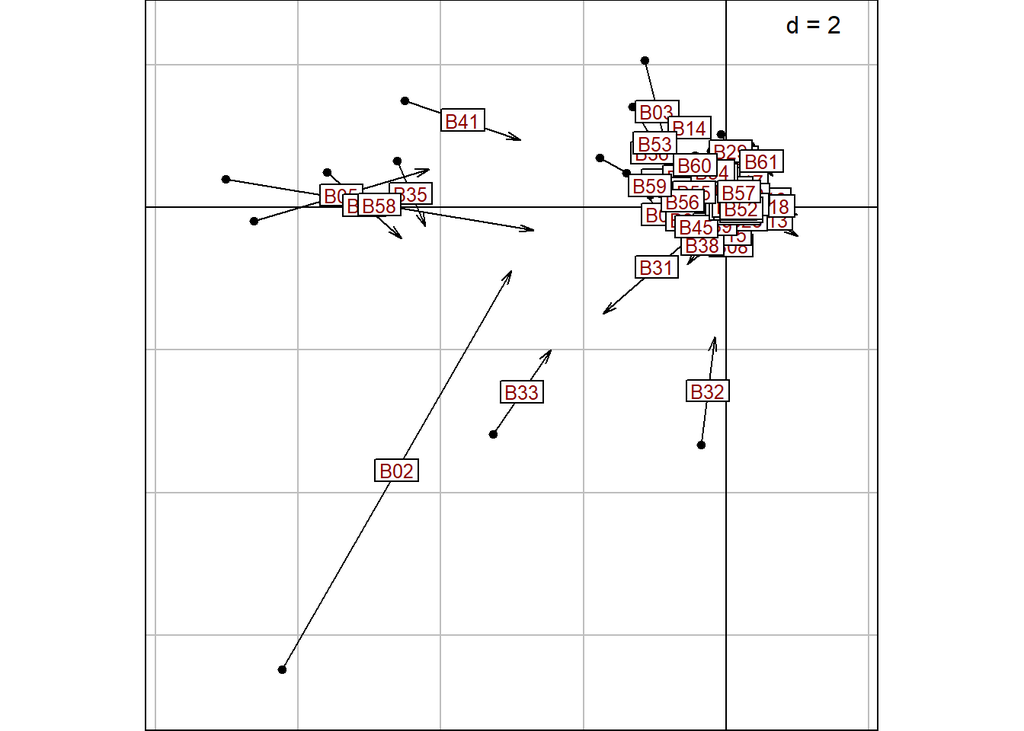

```r
# Invert second axis
ls <- cca_birds$ls
ls[, 2] <- - ls[, 2]

li <- cca_birds$li
li[, 2] <- - li[, 2]

# ls -> li
s.match(ls, li, xax = 1, yax = 2,
        plabels.col = params$colco,
        plabels.cex = 0.8)
```

## Model fit

```r
# Perform the same dc-CA, but with package douconca
fEnv <- interactions ~ meanL + meanD1 + meanHeight + CropMass
fTraits <- interactions ~ KippsIndex + BillLength + BillWidth + Bodymass

dcca_dou <- douconca::dc_CA(
  formulaEnv = fEnv, formulaTraits = fTraits,
  dataEnv = plant_traits, dataTraits = bird_traits,
  divideBySiteTotals = FALSE
  )
```

```
Step 1: the CCA ordination of the transposed matrix with trait constraints,
        useful in itself and also yielding CWMs of the orthonormalized traits for step 2.

Call: cca0(formula = formulaTraits, response = tY, data =
out0$data$dataTraits)

              Inertia Proportion Rank
Total          5.5012     1.0000
Constrained    0.9502     0.1727    4
Unconstrained  4.5510     0.8273   51

Inertia is scaled Chi-square

Eigenvalues for constrained axes:
  CCA1   CCA2   CCA3   CCA4
0.4327 0.2339 0.1760 0.1076

Eigenvalues for unconstrained axes:
CA1 CA2 CA3 CA4 CA5 CA6 CA7 CA8
 NA  NA  NA  NA  NA  NA  NA  NA
(Showing 8 of 51 unconstrained eigenvalues)

mean, sd, VIF and canonical coefficients with their optimistic [!] t-values:
               Avg     SDS    VIF   Regr1   tval1
KippsIndex  0.2102  0.0439 1.0739  0.1744  2.9595
BillLength 16.0176  6.7782 4.2198 -0.5861 -5.0159
BillWidth   8.6214  2.9368 3.9660  0.9760  8.6167
Bodymass   39.6694 81.0778 1.7882  0.2106  2.7691

Step 2: the RDA ordination of CWMs of the orthonormalized traits
        of step 1 with environmental constraints:

Call: wrda(formula = formulaEnv, response = out1$CWMs_orthonormal_traits,
data = out1$data$dataEnv, weights = out1$weights$rows)

              Inertia Proportion Rank
Total          0.9502     1.0000
Constrained    0.2603     0.2740    4
Unconstrained  0.6898     0.7260    4

```

[output cut: 19 more lines]

```
BillLength 16.0176  6.7782 4.2198 0.3894 1.5563
BillWidth   8.6214  2.9368 3.9660 0.2872 1.1839
Bodymass   39.6694 81.0778 1.7882 0.1387 0.8514

               weighted variance
total                      5.501
traits_explain             0.950
env_explain                0.590
constraintsTE              0.260
attr(,"meaning")
               meaning
total          "total inertia (= weighted variation)"
traits_explain "trait-constrained variation"
env_explain    "environment-constrained variation"
constraintsTE  "trait-constrained variation explained by the predictors in formulaEnv"
```

```r
# Eigenvalues by both methods are equal
dcca_dou$eigenvalues/dcca$eig
```

```
dcCA1 dcCA2 dcCA3 dcCA4
    1     1     1     1
```

```r
# Get frequencies predicted by dcCA (backtransform centered matrix on interactions scale)
# dcca$tab corresponds to U %*% Delta %*% V^t (see below)
# tab <- as.matrix(dcca$l1) %*% diag(sqrt(dcca$eig)) %*% t(dcca$c1)
# tab/dcca$tab # = 1
yfit <- sum(interactions) * outer(dcca$lw, dcca$cw) * (1 + as.matrix(dcca$tab))
```

```r
# Get frequencies predicted by dcCA (douconca)
yfit_dou <- fitted(dcca_dou,type = "response")

# douconca and ade4 fits are equal (yfit = yfit_dou)
prec <- 1e-10
all(abs(yfit_dou-yfit) < prec)
```

```
[1] TRUE
```

```r
# Get bird and plants codes/names table
bird_codes <- bird_traits_codes[, c("bird_species_code", "bird_species_name")]
plant_codes <- plant_traits_codes[, c("plant_species_code", "plant_species_name")]
```

```r
# Format data
y_eq_df <- format_fit(interactions, yfit,
                      idcols = colnames(interactions), bcodes = bird_codes)

# Add plant names
y_eq_df <- y_eq_df |>
  dplyr::left_join(plant_codes, by = "plant_species_code")

# Join codes and names
y_eq_df <- y_eq_df |>
  dplyr::mutate(plant_species_name_code = paste0("*", plant_species_name, "*", " (", plant_species_code, ")")) |>
  dplyr::mutate(bird_species_name_code = paste0("*", bird_species_name, "*", " (", bird_species_code, ")"))
```

### By birds

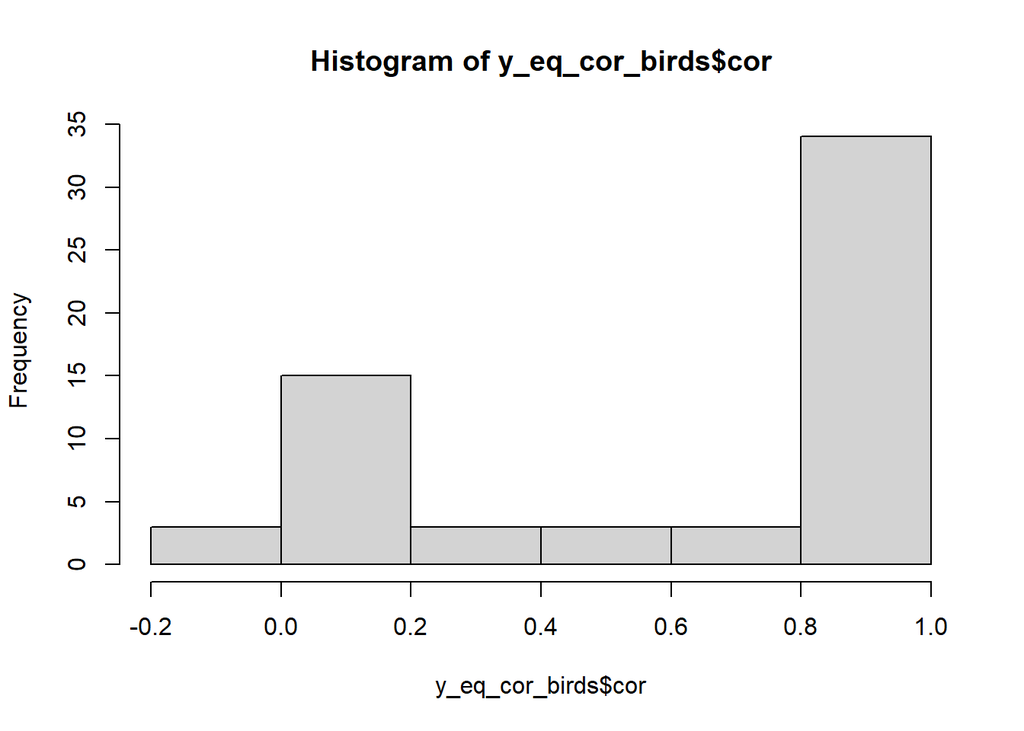

```r
# Get correlations by bird
y_eq_cor_birds <- y_eq_df |>
  dplyr::group_by(bird_species_name_code) |>
  dplyr::summarize(cor = cor(values_x, values_y),
                   n = dplyr::n()) |>
  dplyr::mutate(label = paste("italic(r)==", round(cor, 3)))

hist(y_eq_cor_birds$cor)
```

```r
summary(y_eq_cor_birds$cor)
```

```
    Min.  1st Qu.   Median     Mean  3rd Qu.     Max.
-0.04516  0.15784  0.88171  0.63136  0.98501  0.99728
```

```r
# Proper meta-analytic testing
# Transform raw Pearson's r to Fisher Z
dat <- escalc(measure = "ZCOR",
              ri = y_eq_cor_birds$cor, ni = y_eq_cor_birds$n)

# Fixed-effects model
z_test <- rma.uni(yi, vi, data = dat, method = "FE")
summary(z_test)
```

```
Fixed-Effects Model (k = 61)

    logLik    deviance         AIC         BIC        AICc
-1938.4776   4002.2457   3878.9552   3881.0661   3879.0230

I^2 (total heterogeneity / total variability):   98.50%
H^2 (total variability / sampling variability):  66.70

Test for Heterogeneity:
Q(df = 60) = 4002.2457, p-val < .0001

Model Results:

estimate      se     zval    pval   ci.lb   ci.ub
  1.4158  0.0183  77.4062  <.0001  1.3800  1.4517  ***

---
Signif. codes:  0 '***' 0.001 '**' 0.01 '*' 0.05 '.' 0.1 ' ' 1
```

```r
# Get z estimates reported (mean +- SE)
z_test$b
```

```
            [,1]
intrcpt 1.415836
```

```r
z_test$se
```

```
[1] 0.01829098
```

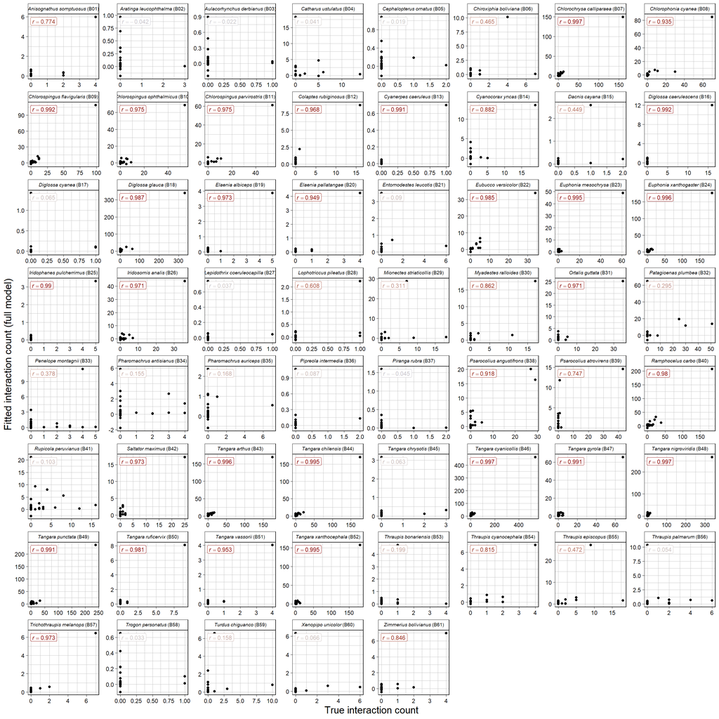

```r
# Plot birds
ggplot(y_eq_df, aes(x = values_x, y = values_y)) +
  xlab("True interaction count") +
  ylab("Fitted interaction count (full model)") +
  geom_point() +
  facet_wrap(facets = vars(bird_species_name_code), scales = "free") +
  geom_label(data = y_eq_cor_birds,
             aes(x = -Inf, y = Inf, label = label, col = cor),
             show.legend = FALSE,
             inherit.aes = FALSE,
             parse = TRUE,
             hjust = -0.1, vjust = 1.4,
             size = 3) +
  scale_color_gradient2(low = "darkblue", mid = "grey80", high = "darkred",
                        midpoint = 0) +
  theme(axis.title = element_text(size = 15),
        strip.text = ggtext::element_markdown(size = 7))
```

```r
ggsave(file.path(figures_folder, "Fig_S1_S10_pred_vs_count_birds_all.png"),
       width = 34, height = 30, units = "cm")
```

### By plants

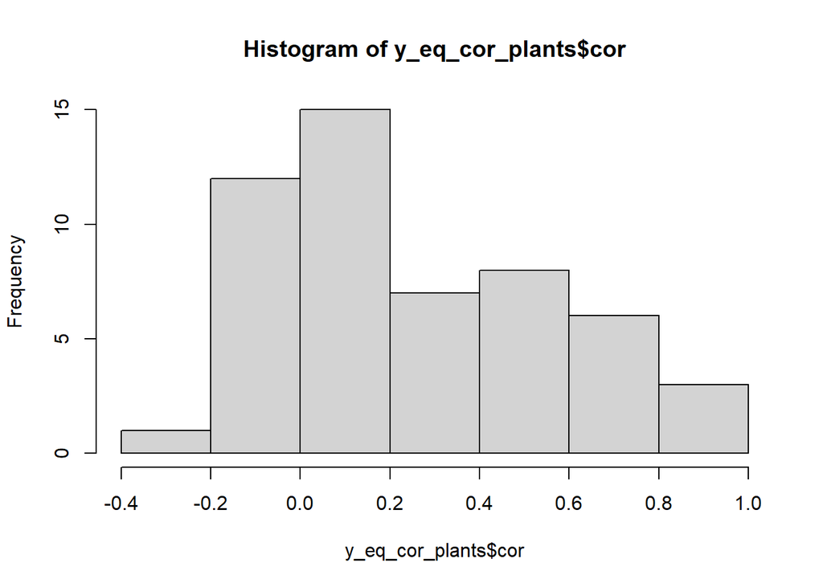

```r
# Get correlations by plants
y_eq_cor_plants <- y_eq_df |>
  dplyr::group_by(plant_species_name_code) |>
  dplyr::summarize(cor = cor(values_x, values_y),
                   n = dplyr::n()) |>
  dplyr::mutate(label = paste("italic(r)==", round(cor, 3)))

hist(y_eq_cor_plants$cor)
```

```r
summary(y_eq_cor_plants$cor)
```

```
     Min.   1st Qu.    Median      Mean   3rd Qu.      Max.
-0.241218  0.007445  0.162061  0.264005  0.509875  0.987468
```

```r
# Proper meta-analytic testing
# Transform raw Pearson's r to Fisher Z
dat <- escalc(measure = "ZCOR",
              ri = y_eq_cor_plants$cor, ni = y_eq_cor_plants$n)

# Fixed-effects model
z_test <- rma.uni(yi, vi, data = dat, method = "FE")
summary(z_test)
```

```
Fixed-Effects Model (k = 52)

   logLik   deviance        AIC        BIC       AICc
-272.5572   660.6878   547.1143   549.0656   547.1943

I^2 (total heterogeneity / total variability):   92.28%
H^2 (total variability / sampling variability):  12.95

Test for Heterogeneity:
Q(df = 51) = 660.6878, p-val < .0001

Model Results:

estimate      se     zval    pval   ci.lb   ci.ub
  0.3363  0.0182  18.4714  <.0001  0.3007  0.3720  ***

---
Signif. codes:  0 '***' 0.001 '**' 0.01 '*' 0.05 '.' 0.1 ' ' 1
```

```r
# Get z estimates reported (mean +- SE)
z_test$b
```

```
             [,1]
intrcpt 0.3363448
```

```r
z_test$se
```

```
[1] 0.01820893
```

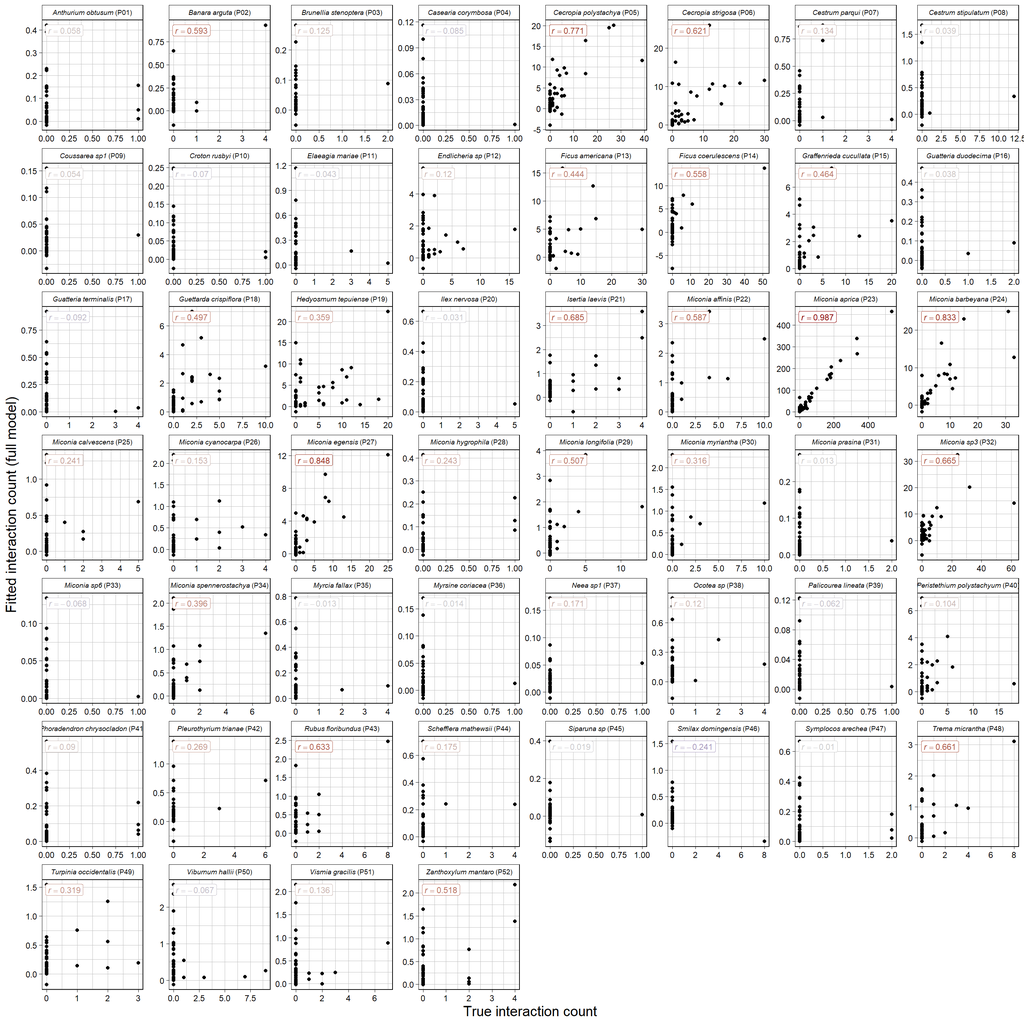

```r
# Plot plants
ggplot(y_eq_df, aes(x = values_x, y = values_y)) +
  xlab("True interaction count") +
  ylab("Fitted interaction count (full model)") +
  geom_point() +
  facet_wrap(facets = vars(plant_species_name_code), scales = "free") +
  geom_label(data = y_eq_cor_plants,
             aes(x = -Inf, y = Inf, label = label, col = cor),
             show.legend = FALSE,
             inherit.aes = FALSE,
             parse = TRUE,
             hjust = -0.1, vjust = 1.4,
             size = 3) +
  scale_color_gradient2(low = "darkblue", mid = "grey80", high = "darkred",
                        midpoint = 0) +
  theme(axis.title = element_text(size = 15),
        strip.text = ggtext::element_markdown(size = 7))
```

```r
ggsave(file.path(figures_folder, "Fig_S1_S11_pred_vs_count_plants_all.png"),
       width = 34, height = 30, units = "cm")
```

### Plot residuals

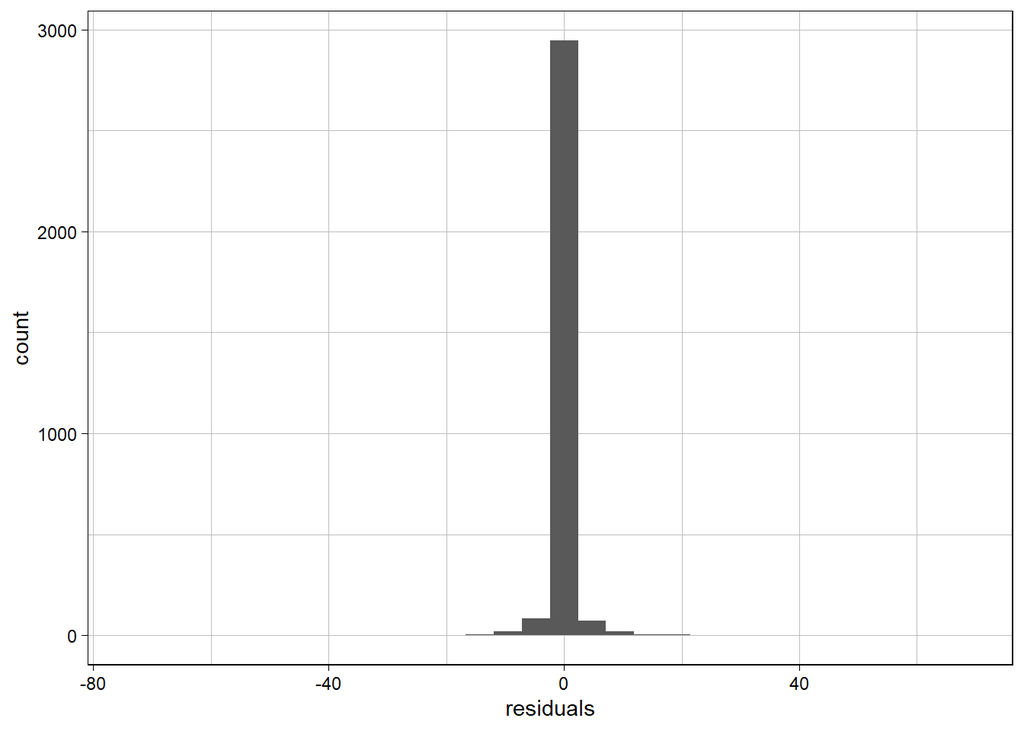

```r
# Plot residuals
resid <- yfit - interactions

resid_df <- as.data.frame(resid) |>
  tibble::rownames_to_column("plant_species_code")

resid_df <- resid_df |>
  tidyr::pivot_longer(cols = 2:ncol(resid_df),
                      names_to = "bird_species_code",
                      values_to = "residuals")

resid_df <- resid_df |>
  dplyr::mutate(bird_species_code = factor(bird_species_code,
                                           levels = rownames(dcca$lsQ)[rank(dcca$lsQ[,1], ties.method = "random")])) |>
  dplyr::mutate(plant_species_code = factor(plant_species_code,
                                           levels = rownames(dcca$lsR)[rank(dcca$lsR[,1], ties.method = "random")]))

ggplot(resid_df) +
  geom_histogram(aes(x = residuals))
```

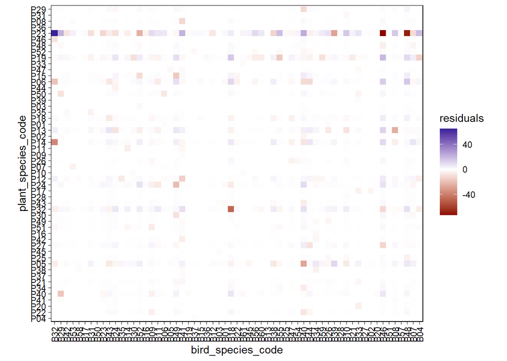

```r
ggplot(resid_df, aes(x = bird_species_code, y = plant_species_code)) +
  geom_tile(aes(fill = residuals)) +
  scale_fill_gradient2(low = "darkred", mid = "white", high = "darkblue",
                       midpoint = 0) +
  coord_equal() +
  theme(axis.text.x = element_text(angle = 90, vjust = 0.5))
```

## Prediction

In this section we perform the prediction experiment described in Appendix S1, Section S9.

```r
# Select bird species to predict
# id_birds <- sample(1:ncol(interactions), size = 3, replace = FALSE)
id_birds <- c(46, 33, 34)

names(id_birds)  <- colnames(interactions)[id_birds]

# Get initially predicted interactions for test birds
ytest_true <- yfit[, id_birds]
ytest_true_dou <- yfit_dou[, id_birds]
```

### Train dc-CA

For this, we first fit dc-CA on training data (i.e. interaction matrix without the 3 birds).

```r
# ade4
interactions_train <- interactions[, -id_birds]
bird_traits_train <- bird_traits[-id_birds, ]

interactions_test <- interactions[, id_birds]
bird_traits_test <- bird_traits[id_birds, ]

ca_train <- dudi.coa(interactions_train,
                     scannf = FALSE,
                     nf = min(dim(interactions_train) - 1))
dcca_train <- dpcaiv(dudi = ca_train,
                     dfR = plant_traits,
                     dfQ = bird_traits_train,
                     nf = min(k, l),
                     scannf = FALSE)

# douconca
dcca_train_dou <- dc_CA(
  formulaEnv = fEnv, formulaTraits = fTraits,
  dataEnv = plant_traits, dataTraits = bird_traits_train,
  response = interactions_train,
  divideBySiteTotals = FALSE)
```

```
Step 1: the CCA ordination of the transposed matrix with trait constraints,
        useful in itself and also yielding CWMs of the orthonormalized traits for step 2.

Call: cca0(formula = formulaTraits, response = tY, data =
out0$data$dataTraits)

              Inertia Proportion Rank
Total          5.8668     1.0000
Constrained    0.7956     0.1356    4
Unconstrained  5.0712     0.8644   49

Inertia is scaled Chi-square

Eigenvalues for constrained axes:
  CCA1   CCA2   CCA3   CCA4
0.3751 0.2488 0.1042 0.0675

Eigenvalues for unconstrained axes:
CA1 CA2 CA3 CA4 CA5 CA6 CA7 CA8
 NA  NA  NA  NA  NA  NA  NA  NA
(Showing 8 of 49 unconstrained eigenvalues)

mean, sd, VIF and canonical coefficients with their optimistic [!] t-values:
               Avg     SDS    VIF   Regr1   tval1
KippsIndex  0.2080  0.0449 1.2348  0.1635  2.2488
BillLength 16.2622  7.0757 4.5206 -0.5643 -4.0555
BillWidth   8.6652  2.9710 4.5542  1.0004  7.1628
Bodymass   39.0293 71.0629 1.8797  0.1159  1.2918

Step 2: the RDA ordination of CWMs of the orthonormalized traits
        of step 1 with environmental constraints:

Call: wrda(formula = formulaEnv, response = out1$CWMs_orthonormal_traits,
data = out1$data$dataEnv, weights = out1$weights$rows)

              Inertia Proportion Rank
Total          0.7956     1.0000
Constrained    0.2730     0.3432    4
Unconstrained  0.5226     0.6568    4

```

[output cut: 19 more lines]

```
BillLength 16.2622  7.0757 4.5206 0.2217 0.8456
BillWidth   8.6652  2.9710 4.5542 0.2828 1.0747
Bodymass   39.0293 71.0629 1.8797 0.2500 1.4790

               weighted variance
total                      5.867
traits_explain             0.796
env_explain                0.613
constraintsTE              0.273
attr(,"meaning")
               meaning
total          "total inertia (= weighted variation)"
traits_explain "trait-constrained variation"
env_explain    "environment-constrained variation"
constraintsTE  "trait-constrained variation explained by the predictors in formulaEnv"
```

### Predict test data

Then, we predict interactions for the 3 bird species from the coefficients obtained by training in the precedent step.

```r
# Get predicted values (ade4) -----
# Apply same scaling used for the train dataset to bird_traits
w <- dcca_train$cw
mu <- apply(bird_traits_train, 2, weighted.mean, w = w)
sd <- sapply(1:ncol(bird_traits_train),
             function(i) sqrt(sum(w * (bird_traits_train[, i] - mu[i])^2)/sum(w)))
bird_traits_test_sc <- scale(bird_traits_test, center = mu, scale = sd)

# Regress traits with coefficients
co_test <- as.matrix(cbind(1, bird_traits_test_sc)) %*% as.matrix(dcca_train$faQ)
c1_test <- sweep(co_test, 2, sqrt(dcca_train$eig), "/")

# # Test on same data used for fitting
# bird_traits_train_sc <- scale(bird_traits_train, center = mu, scale = sd)
# co_test <- as.matrix(cbind(1, bird_traits_train_sc)) %*% as.matrix(dcca_train$faQ)
# co_test/dcca_train$co
# c1_test <- sweep(co_test, 2, sqrt(dcca_train$eig), "/")
# c1_test/dcca_train$c1 # is equal

# Reconstruct fitted values
# Here we use other weights than the original ni. / n.j
# because we don't know weights a priori for the predicted values
tab_test <- as.matrix(dcca_train$l1) %*% diag(sqrt(dcca_train$eig)) %*% t(c1_test)
cw_sub <- rep(1/length(id_birds), length(id_birds))
lw_sub <- rep(1/nrow(interactions_train), nrow(interactions_train))

ytest <- 1/sum(cw_sub) * outer(lw_sub, cw_sub) * (1 + tab_test)

# Get predicted values (douconca) -----
ytest_dou <- predict(
  dcca_train_dou, type = "response",
  newdata = list(traits = bird_traits_test,
                 env = plant_traits))
```

Finally, we get the fitted values computed with the whole model, but with the weights used for prediction.

```r
# Get predicted values from first model (using unit weights)
ytest_true_w <- 1/sum(cw_sub) * outer(lw_sub, cw_sub) * (1 + dcca$tab[, id_birds])
```

### Plots

First, compare predictions to interactions counts from data:

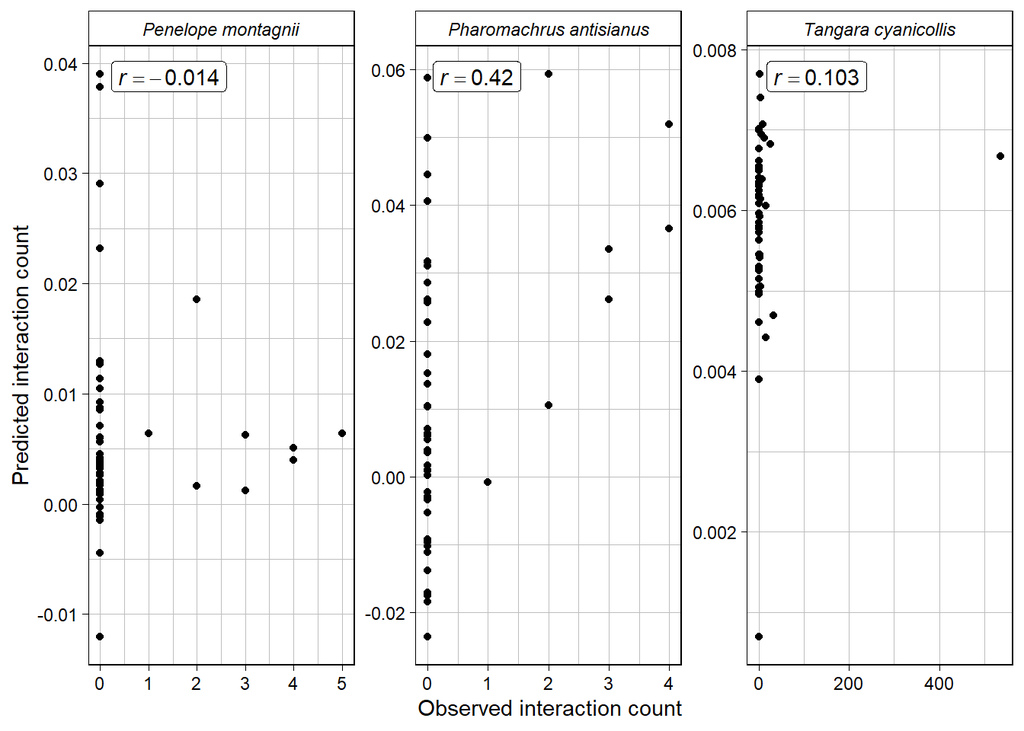

```r
# Compare to data

# Format data
y_df <- format_fit(interactions[,id_birds], ytest,
                   idcols = names(id_birds), bcodes = bird_codes)

# Get correlations
y_cor <- y_df |>
  dplyr::group_by(bird_species_name) |>
  dplyr::summarize(cor = cor(values_x, values_y)) |>
  dplyr::mutate(label = paste("italic(r)==", round(cor, 3)))

# Plot
ggplot(y_df, aes(x = values_x, y = values_y)) +
  xlab("Observed interaction count") +
  ylab("Predicted interaction count") +
  geom_point() +
  facet_wrap(facets = vars(bird_species_name), scales = "free") +
  geom_label(data = y_cor,
             aes(x = -Inf, y = Inf, label = label),
             inherit.aes = FALSE,
             parse = TRUE,
             hjust = -0.2, vjust = 1.5) +
  theme(strip.text = element_text(face = "italic"))
```

```r
ggsave(file.path(figures_folder, "Fig_S1_S12a_pred_vs_count.png"),
       width = 20, height = 7, units = "cm")
```

Next, we compare to the fitted counts (fitted on the whole interaction matrix, and reweighted)

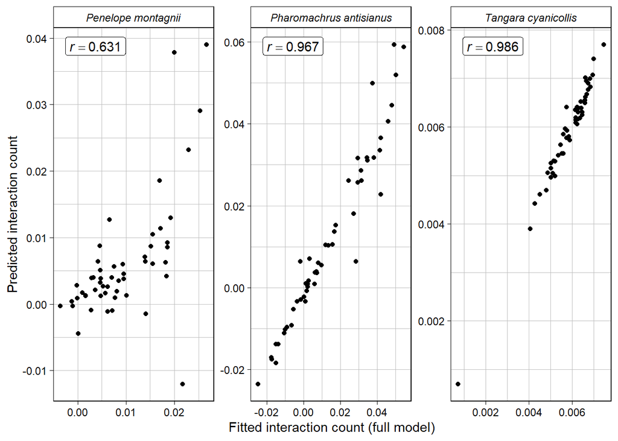

```r
# Compare to fitted data (whole matrix)

# Format data
y_df <- format_fit(ytest_true_w, ytest,
                   idcols = names(id_birds), bcodes = bird_codes)

# Get correlations
y_cor <- y_df |>
  dplyr::group_by(bird_species_name) |>
  dplyr::summarize(cor = cor(values_x, values_y)) |>
  dplyr::mutate(label = paste("italic(r)==", round(cor, 3)))

# Plot
ggplot(y_df, aes(x = values_x, y = values_y)) +
  xlab("Fitted interaction count (full model)") +
  ylab("Predicted interaction count") +
  geom_point() +
  facet_wrap(facets = vars(bird_species_name), scales = "free") +
  geom_label(data = y_cor,
             aes(x = -Inf, y = Inf, label = label),
             inherit.aes = FALSE,
             parse = TRUE,
             hjust = -0.2, vjust = 1.5) +
  theme(strip.text = element_text(face = "italic"))
```

```r
ggsave(file.path(figures_folder, "Fig_S1_S12b_pred_vs_pred.png"),
       width = 20, height = 7, units = "cm")
```

## References

Dehling, D. Matthias, Irene M. A. Bender, Pedro G. Blendinger, Marcia C. Muñoz, Marta Quitián, Francisco Saavedra, Vinicio Santillán, Katrin Böhning-Gaese, Eike-Lena Neuschulz, and Matthias Schleuning. 2021. “ANDEAN Frugivory: Data on Plantbird Interactions and Functional Traits of Plant and Bird Species from Montane Forests Along the Andes.” https://doi.org/10.5061/DRYAD.WM37PVMN5.

Peres-Neto, Pedro R., Pierre Legendre, Stéphane Dray, and Daniel Borcard. 2006. “Variation Partitioning of Species Data Matrices: Estimation and Comparison of Fractions.” *Ecology* 87 (10): 2614–25. https://doi.org/10.1890/0012-9658(2006)87[2614:VPOSDM]2.0.CO;2.